# act_report

## Report: act_report

- Create a **250-word-minimum written report** called "act_report.pdf" or "act_report.html" that communicates the insights and displays the visualization(s) produced from your wrangled data. This is to be framed as an external document, like a blog post or magazine article, for example.

## Introduction

WeRateDogs is a Twitter account that rates people's dogs with a humorous comment about the dog. These ratings almost always have a denominator of 10. The numerators, though? Almost always greater than 10. 11/10, 12/10, 13/10, etc. Why? Because "they're good dogs Brent." WeRateDogs has over 4 million followers and has received international media coverage. I have used thier twitter archive data to anlysis some facts on tweets related to dogs

### Sources of Data

Most of the users (almost 95%) are using Twitter for iPhone for checking out tweets and interacting with twitter which is expected due to popularity of Twitter mobile usage as compared to Vine, TweetDeck or Twitter Web

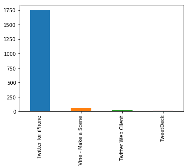

### Pupper is the most loved dog stage

Almost 65% of the tweets were recieved for dogs in thier pupper stage.

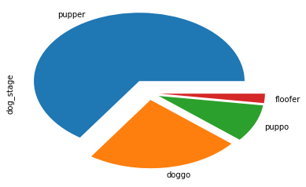

### Top 5 Most Popular Dog Breeds

Golden Retriever, Pembroke, Labrador, Chihuahua and Pug are the most loved dogs among all. ALmost 25% of the total tweets belong to these 5 Breeds only.

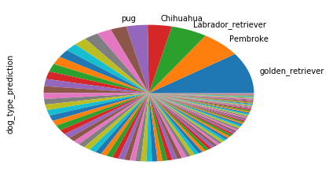

### Popularity vs Ratings

Dogs having more ratings have more likes as well. Yayy!!! Twitter followers do agree with WeRateDogs ratings.

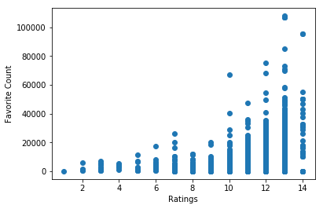